# Assignment 0909

# 3.R Basics

## 3.7 Vectors

In R, the most basic objects available to store data are vectors. As we have seen, complex datasets can usually be broken down into components that are vectors.

### 3.7.1 Creating vectors

We can create vectors with using function ‘c’, which stands for concatenate(to join or link together, as though in a chain).

```r
codes <- c(380, 124, 818)
codes
```

```
[1] 380 124 818
```

Also, vectors can contain characters with double quotes:

```r
country <- c("italy", "canada", "egypt")
```

And single quotes:

```r
country <- c('italy', 'canada', 'egypt')
```

If we do not use any quotes, the function would not work well. since that words would be recognized as undefined variables.

```r
country <- c(italy, canada, egypt)
```

```
Error: object 'italy' not found
```

### 3.7.2 Names

When we use vector, we can name the entries to connect two types of values.

## 3.8 Coercion[강제, 강압]

In the case of the vectors of R, all of the elements of any vectors must be identical. So, if there is any values of unexpected types in vectors, those must be changed into proper type. We call it “coercion.”

If we run this we might think we would get an error;

```r
x <- c(1, \canada\, 3)
```

but we didn`t.

the numerics(or intgers) are converted into charcters automatically.

This function is actually quite useful since datasets that include numbers as character strings are common.

### 3.8.1 Not availables (NA)

If we coerced a value to be converted into some type which would not express that value, than the value would be replaced with special value called an ‘NA’ for “not available”.

## 3.9 Exercises

1. Use the function ‘c’ to create a vector with the average high temperatures in January for Beijing, Lagos, Paris, Rio de Janeiro, San Juan and Toronto, which are 35, 88, 42, 84, 81, and 30 degrees Fahrenheit. Call the object ‘temp’.

```r
temp = c(35, 88, 42, 84, 81, 30)
```

2. Now create a vector with the city names and call the object ‘city’.

```r
city <- c(\Beijing\, \Lagos\, \Paris\, \Rio de Janeiro\, \San Juan\, \Toronto\)
```

3. Use the names function and the objects defined in the previous exercises to associate the temperature data with its corresponding city.

```r
names(temp) <- city
```

```r
temp[c(\Paris\, \San Juan\)]
```

```
   Paris San Juan
      42       81
```

6. Use the ‘:’ operator to create a sequence of numbers  
   12, 13, 14, …, 73.

```r
12:73
```

```
 [1] 12 13 14 15 16 17 18 19 20 21 22 23 24 25 26 27 28 29
[19] 30 31 32 33 34 35 36 37 38 39 40 41 42 43 44 45 46 47
[37] 48 49 50 51 52 53 54 55 56 57 58 59 60 61 62 63 64 65
[55] 66 67 68 69 70 71 72 73
```

```r
seq(2,100,2)
```

```
 [1]   2   4   6   8  10  12  14  16  18  20  22  24  26  28
[15]  30  32  34  36  38  40  42  44  46  48  50  52  54  56
[29]  58  60  62  64  66  68  70  72  74  76  78  80  82  84
[43]  86  88  90  92  94  96  98 100
```

8. Create a vector of numbers that starts at 6, does not pass 55, and adds numbers in increments of 4/7: 6, 6+4/7, 6+8/7, etc.. How many numbers does the list have? Hint: use ‘seq’ and ‘length’.

```r
a <- seq(6, 55, 4/7)
length(a)
```

```
[1] 86
```

9. What is the class of the following object ‘a <- seq(1, 10, 0.5)’?

```r
a <- seq(1, 10, 0.5)
class(a)
```

```
[1] \numeric\
```

10. What is the class of the following object ‘a <- seq(1, 10)’?

```r
a <- seq(1, 10)
class(a)
```

```
[1] \integer\
```

11. The class of ‘class(a<-1)’ is numeric, not integer. R defaults to numeric and to force an integer, you need to add the letter ‘L’. Confirm that the class of ‘1L’ is integer.

```r
class(1)
```

```
[1] \numeric\
```

```r
class(1L)
```

```
[1] \integer\
```

12. Define the following vector: ‘x <- c(“1”, “3”, “5”)’ and coerce it to get integers.

```r
x <- c(\1\, \3\, \5\)
as.integer(x)
```

```
[1] 1 3 5
```

## 3.10 Sorting

In this part, we would learn functions about sorting by data of murders.

### 3.10.1 ‘sort’

When we use the function ‘sort’, the vector would sorted in increasing order.

For example:

```r
library(dslabs)
data(murders)
sort(murders$total)
```

```
 [1]    2    4    5    5    7    8   11   12   12   16   19
[12]   21   22   27   32   36   38   53   63   65   67   84
[23]   93   93   97   97   99  111  116  118  120  135  142
[34]  207  219  232  246  250  286  293  310  321  351  364
[45]  376  413  457  517  669  805 1257
```

### 3.10.2 ‘order’

The function ‘sort’ sorts input vector and returns sorted one:

```r
x <- c(31, 4, 15, 92, 65)
sort(x)
```

```
[1]  4 15 31 65 92
```

In the case of the function ‘order’, returns the index that sorts input vector:

```r
index <- order(x)
x[index]
```

```
[1]  4 15 31 65 92
```

In other words, we can get a vector about the order of input vector: the first number is the order of the smallest/fastest element, and the last number is that of the biggest/latest element.

For example, data of murders are ordered by:

```r
murders$state[1:10]
```

```
 [1] \Alabama\              \Alaska\
 [3] \Arizona\              \Arkansas\
 [5] \California\           \Colorado\
 [7] \Connecticut\          \Delaware\
 [9] \District of Columbia\ \Florida\
```

```r
murders$abb[1:10]
```

```
 [1] \AL\ \AK\ \AZ\ \AR\ \CA\ \CO\ \CT\ \DE\ \DC\ \FL\
```

alphabetic order.

When we order it by number of total murders:

```r
ind <- order(murders$total)
murders$abb[ind]
```

```
 [1] \VT\ \ND\ \NH\ \WY\ \HI\ \SD\ \ME\ \ID\ \MT\ \RI\ \AK\
[12] \IA\ \UT\ \WV\ \NE\ \OR\ \DE\ \MN\ \KS\ \CO\ \NM\ \NV\
[23] \AR\ \WA\ \CT\ \WI\ \DC\ \OK\ \KY\ \MA\ \MS\ \AL\ \IN\
[34] \SC\ \TN\ \AZ\ \NJ\ \VA\ \NC\ \MD\ \OH\ \MO\ \LA\ \IL\
[45] \GA\ \MI\ \PA\ \NY\ \FL\ \TX\ \CA\
```

### 3.10.3 ‘max’ and ‘which.max’

We can find the maximum value with the function ‘max’:

```r
max(murders$total)
```

```
[1] 1257
```

and the order of the maximum value with the function ‘which.max’:

```r
i_max <- which.max(murders$total)
murders$state[i_max]
```

```
[1] \California\
```

We can find mimimum in the same way by using ‘min’ and ‘which.min’

### 3.10.4 ‘rank’

The function ‘rank’ returns a vector indicates the order of the corresponding value.

```r
x <- c(31, 4, 15, 92, 65)
rank(x)
```

### 3.10.5 Beware of recycling

If we do some operation with vectors which have different lenght, the shorter vector is filled with values of itself elementwise. We call it “recycling.”

```r
x <- c(1,2,3)
y <- c(10, 20, 30, 40, 50, 60, 70)
x+y
```

## 3.11 Exercise

```r
x <- c(1,2,3)
y <- c(10, 20, 30, 40, 50, 60, 70)
x+y
```

1. Use the ‘$’ operator to access the population size data and store it as the object ‘pop’. Then use the ‘sort’ function to redefine ‘pop’ so that it is sorted. Finally, use the ‘[’ operator to report the smallest population size.

```r
pop <- murders$population
pop <- sort(pop)
pop[1]
```

2. Now instead of the smallest population size, find the index of the entry with the smallest population size. Hint: use ‘order’ instead of ‘sort’.

```r
pop <- murders$population
pop <- order(pop)
pop[1]
```

3. We can actually perform the same operation as in the previous exercise using the function ‘which.min’. Write one line of code that does this.

```r
which.min(murders$population)
```

4. Now we know how small the smallest state is and we know which row represents it. Which state is it? Define a variable ‘states’ to be the state names from the ‘murders’ data frame. Report the name of the state with the smallest population.

```r
states <- murders$state
states[which.min(murders$population)]
```

5. You can create a data frame using the ‘data.frame’ function. Here is a quick example:

```r
temp <- c(35, 88, 42, 84, 81, 30)
city <- c(\Beijing\, \Lagos\, \Paris\, \Rio de Janeiro\, \San Juan\, \Toronto\)
city_temps <- data.frame(name = city, temperature = temp)
```

Use the ‘rank’ function to determine the population rank of each state from smallest population size to biggest. Save these ‘ranks’ in an object called ranks, then create a data frame with the state name and its rank. Call the data frame ‘my_df’.

```r
ranks <- rank(murders$population)
my_df <- data.frame(state = murders$state, rank = ranks)
```

6. Repeat the previous exercise, but this time order ‘my_df’ so that the states are ordered from least populous to most populous. Hint: create an object ‘ind’ that stores the indexes needed to order the population values. Then use the bracket operator ‘[’ to re-order each column in the data frame.

```r
ind <- order(murders$population)
my_df <- data.frame(state = murders$state[ind], abb = murders$abb[ind], region = murders$region[ind], population = murders$population[ind], total = murders$total[ind])
```

7. The ‘na_example’ vector represents a series of counts. You can quickly examine the object using:

```r
data(\na_example\)
str(na_example)
```

However, when we compute the average with the function ‘mean’, we obtain an ‘NA’:

```r
mean(na_example)
```

The ‘is.na’ function returns a logical vector that tells us which entries are ‘NA’. Assign this logical vector to an object called ‘ind’ and determine how many ‘NA’s does ’na_example’ have.

```r
table(is.na(na_example))
```

The answer is 145.

8. Now compute the average again, but only for the entries that are not ‘NA’. Hint: remember the ‘!’ operator.

```r
mean(na_example, na.rm = T)
```

## 3.12 Vector arithmetics

```r
library(dslabs)
data(\murders\)
murders$state[which.max(murders$population)]
```

is California.

But we should consider about population of each states.

### 3.12.1 Rescaling a vector

If we conduct arithmetic operations on vectors, it occur elementwise.

```r
inches <- c(69, 62, 66, 70, 70, 73, 67, 73, 67, 70)
```

For example, we can muiltifly the vector ‘inches’ with a number ‘2.54’:

```r
inches * 2.54
```

Similarly, we can subtract some number from the vector:

```r
inches - 69
```

### 3.12.2 Two vectors

When we conduct arithmetic operations with two vectors(same length), calculate between values in the same order. (a_1, a_2, a_3, …, a_n) + (b_1, b_2, b_3, …, b_n) = (a_1+b_1, a_2+b_2, a_3+b_3, …, a_n+a_n)

Therefore we can calculate murder rate of each state by dividing murders by population and multiflying 100000:

```r
murder_rate <- murders$total / murders$population * 100000
```

And we can sort in order of murder rate:

```r
murders$state[order(murder_rate)]
```

## 3.13 Exercises

1.Previously we created this data frame:

```r
temp <- c(35, 88, 42, 84, 81, 30)
city <- c(\Beijing\, \Lagos\, \Paris\, \Rio de Janeiro\, \San Juan\, \Toronto\)
city_temps <- data.frame(name = city, temperature = temp)
```

1. Remake the data frame using the code above, but add a line that converts the temperature from Fahrenheit to Celsius. The conversion is C=5/9×(F−32).

```r
temp <- c(35, 88, 42, 84, 81, 30)
temp <- ( temp - 32 ) * 5 / 9
city <- c(\Beijing\, \Lagos\, \Paris\, \Rio de Janeiro\, \San Juan\, \Toronto\)
city_temps <- data.frame(name = city, temperature = temp)
```

```r
c <- 1:100
sum(1/c^2)
```

3. Compute the per 100,000 murder rate for each state and store it in the object murder_rate. Then compute the average ‘murder rate’ for the US using the function ‘mean’. What is the average?

```r
murder_rate <- murders$total / murders$population * 100000
mean(murder_rate)
```

## 3.14 Indexing

```r
library(dslabs)
data(\murders\)
```

### 3.14.1 Subsetting with logicals

The murder rate is:

```r
murder_rate <- murders$total / murders$population * 100000
```

If we have a criteria that the murder rate of the state would be lower than 0.71, we can easily find and order it:

```r
ind <- murder_rate < 0.71
```

We can include 0.71:

```r
ind <- murder_rate <= 0.71
ind
```

And we can find which states have murder rate lower than 0.71:

```r
murders$state[ind]
```

Or, how many states do:

```r
sum(ind)
```

### 3.14.2 Logical operators

We can hand logical(boolian) data with logical operators.

One of typical logical operator is ‘&’ for “and” that returns ‘TRUE’ when two are ‘TRUE’ both and returns “FALSE” in other case.

```r
TRUE & TRUE
TRUE & FALSE
FALSE & FALSE
```

For example:

```r
west <- murders$region == \West\
safe <- murder_rate <= 1
```

We can bind them with operator ‘&’:

```r
ind <- safe & west
murders$state[ind]
```

### 3.14.3 ‘which’

Function ‘which’ would select elements that meets some criteria:

```r
ind <- which(murders$state == \California\)
murder_rate[ind]
```

### 3.14.4 ‘match’

We can use function ‘match’ to select several elements with another vector.

```r
ind <- match(c(\New York\, \Florida\, \Texas\), murders$state)
ind
```

And we can find the murder rates that:

```r
murder_rate[ind]
```

### 3.14.5 ‘%in%’

Rather than find the data about the vector, function ‘%in%’ finds whether some elements are present in the vector:

```r
c(\Boston\, \Dakota\, \Washington\) %in% murders$state
```

The function ‘match’ and the combination of ‘which’ and ‘%in%’ work similar. But there is some difference.

```r
match(c(\New York\, \Florida\, \Texas\), murders$state)
which(murders$state%in%c(\New York\, \Florida\, \Texas\))
```

## 3.15 Exercise

```r
library(dslabs)
data(murders)
```

1. Compute the per 100,000 murder rate for each state and store it in an object called `murder_rate`. Then use logical operators to create a logical vector named `low` that tells us which entries of `murder_rate` are lower than 1.

```r
murder_rate <- murders$total / murders$population * 100000
low <- murder_rate < 1
```

2. Now use the results from the previous exercise and the function ‘which’ to determine the indices of ‘murder_rate’ associated with values lower than 1.

```r
which(low)
```

3. Use the results from the previous exercise to report the names of the states with murder rates lower than 1.

```r
murders$state[which(low)]
```

4. Now extend the code from exercise 2 and 3 to report the states in the Northeast with murder rates lower than 1. Hint: use the previously defined logical vector ‘low’ and the logical operator ‘&’.

```r
reg <- murders$region == \Northeast\
ind <- reg & low
murders$state[ind]
```

5. In a previous exercise we computed the murder rate for each state and the average of these numbers. How many states are below the average?

```r
murders$state[which(murder_rate < mean(murder_rate))]
```

6. Use the ‘match’ function to identify the states with abbreviations AK, MI, and IA. Hint: start by defining an index of the entries of ‘murders$abb’ that match the three abbreviations, then use the ‘[’ operator to extract the states.

```r
murders$state[order(match(murders$abb, c(\AK\, \MI\, \IA\)))[1:3]]
```

7. Use the ‘%in%’ operator to create a logical vector that answers the question: which of the following are actual abbreviations: MA, ME, MI, MO, MU?

```r
temp <- c(\MA\, \ME\, \MI\, \MO\, \MU\)
temp[temp%in%murders$abb]
```

8. Extend the code you used in exercise 7 to report the one entry that is not an actual abbreviation. Hint: use the ‘!’ operator, which turns ‘FALSE’ into ‘TRUE’ and vice versa, then ‘which’ to obtain an index.

```r
temp <- c(\MA\, \ME\, \MI\, \MO\, \MU\)
temp[!(temp%in%murders$abb)]
```

## 3.16 Basic Plots

### 3.16.1 ‘plot’

The ‘plot’ function can be used to make scatterplots.

```r
x <- murders$population / 10^6
y <- murders$total

plot(x, y)
```

[output not shown]

We can pick two variables from one data frame by using function ‘with’.

```r
with(murders, plot(population, total))
```

[output not shown]

### 3.16.2 ‘hist’

We can visualize distribution of data. We can find it by simply typing ‘hist’:

```r
x <- with(murders, total / population * 100000)
hist(x)
```

[output not shown]

And we can find which district is the most.

```r
murders$state[which.max(x)]
```

```
[1] \District of Columbia\
```

### 3.16.3 ‘boxplot’

Boxplots provide a more terse summary than histograms, but they are easier to stack with other boxplots.

```r
murders$rate <- with(murders, total / population * 100000)
boxplot(rate~region, data = murders)
```

[output not shown]

### 3.16.4 ‘image’

We can image the data with color.

```r
x <- matrix(1:120, 12, 10)
image(x)
```

[output not shown]

## 3.17 Exercise

1. We made a plot of total murders versus population and noted a strong relationship. Not surprisingly, states with larger populations had more murders.

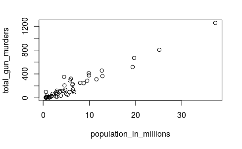

```r
library(dslabs)
data(murders)
population_in_millions <- murders$population/10^6
total_gun_murders <- murders$total
plot(population_in_millions, total_gun_murders)
```

Keep in mind that many states have populations below 5 million and are bunched up. We may gain further insights from making this plot in the log scale. Transform the variables using the ‘log10’ transformation and then plot them.

```r
population_in_log_scale <- log10(murders$population)
total_gun_murders <- murders$total
plot(population_in_log_scale, total_gun_murders)
```

[output not shown]

2. Create a histogram of the state populations.

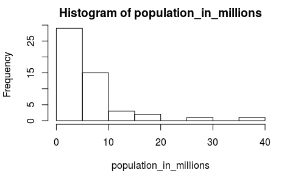

```r
population_in_millions <- with(murders, population / 1000000)
hist(population_in_millions)
```

3. Generate boxplots of the state populations by region.

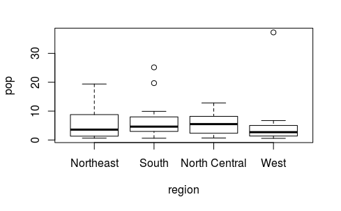

```r
murders$pop <- with(murders, population / 1000000)
boxplot(pop~region, data=murders)
```